# Презентация по лабораторной работе №6

Имитационное моделирование

Соколова Александра Олеговна

1132236034@rudn.ru

Российский университет дружбы народов

2026-05-01

## Цель работы

Освоить методологию моделирования эпидемиологических процессов с использованием аппарата сетей Петри на примере классической модели SIR (Susceptible–Infectious–Recovered). Научиться строить сети Петри для описания переходов между состояниями, проводить детерминированное (ODE) и стохастическое (алгоритм Гиллеспи) имитационное моделирование, анализировать чувствительность модели к изменению параметров, визуализировать динамику эпидемии и создавать анимационные GIF-файлы для наглядного представления распространения инфекции.

## Подготовка рабочего пространства

Создаем проект DrWatson для выполнения лабораторной работы и загружаем необходимые пакеты (рис. 1).

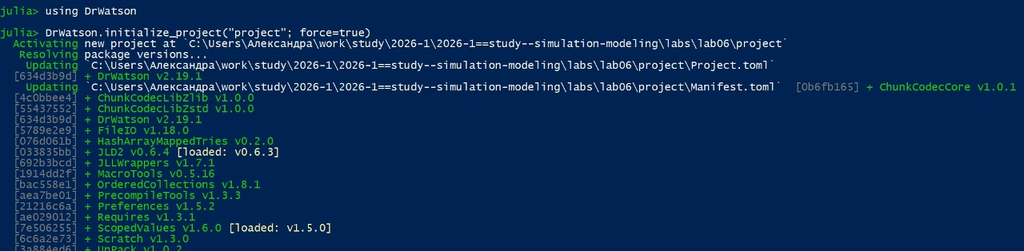

Рисунок 1: Создание рабочего каталога

## Основная программа

Создаем файл src/SIRPetri.jl и записываем туда код модели из методички (рис. 2).

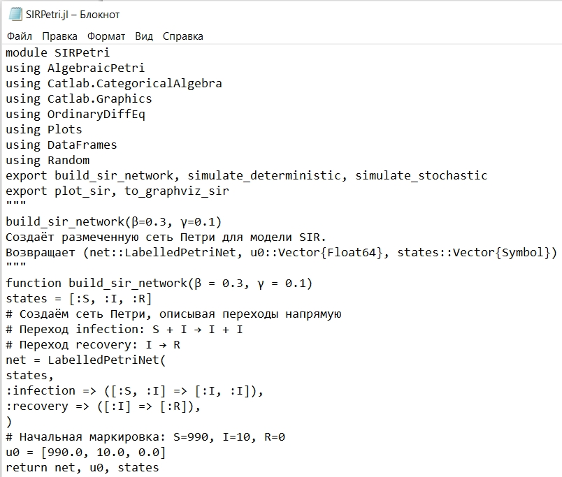

Рисунок 2: Содержимое файла src/SIRPetri.jl

## Базовый прогон модели

Создаем файл scripts/sirpetri_run.jl и добавляем туда скрипт из методички для реализации базового прогона модели (рис. 3).

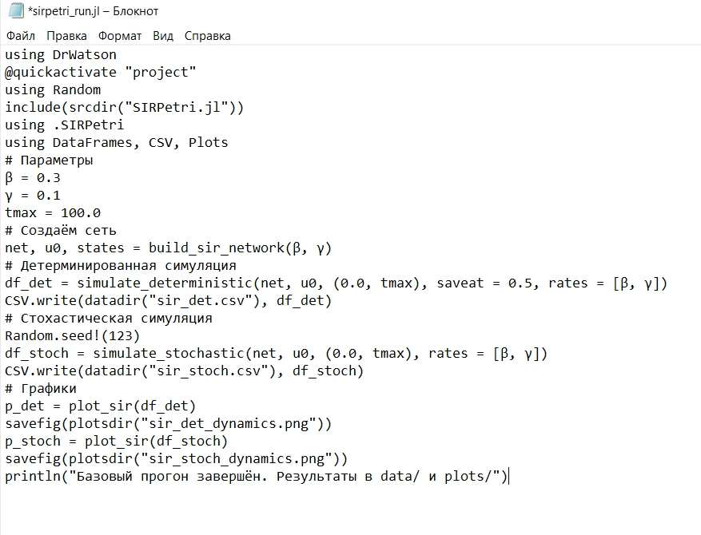

Рисунок 3: Содержимое файла sirpetri_run.jl

## Базовый прогон модели

Запускаем scripts/sirpetri_run.jl командой “julia –project=. scripts/sirpetri_run.jl”. Графики сохраняются в папку “plots” (рис. 4).

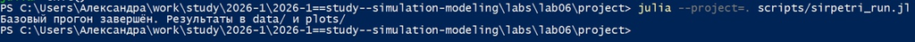

Рисунок 4: Запуск sirpetri_run.jl

## Базовый прогон модели

Просмотрим результаты в папке “Plots”.

— Стохастический график может иметь шумы и, возможно, немного отличаться по времени пика и амплитуде – это демонстрирует влияние случайности.

## Базовый прогон модели

sir_det_dynamics.png (рис. 5).

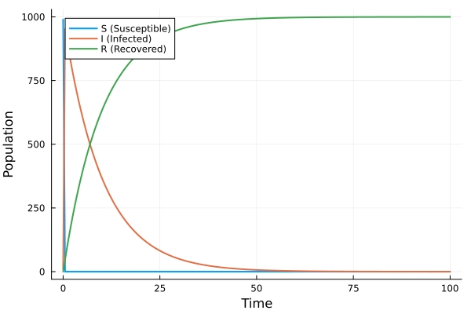

Рисунок 5: Детерминистический график динамики SIR

## Базовый прогон модели

sir_stoch_dynamics.png (рис. 6).

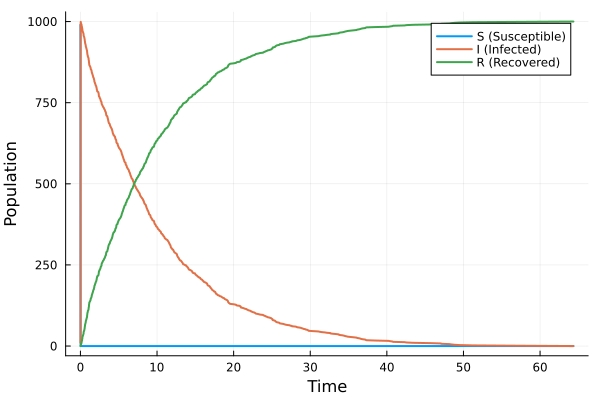

Рисунок 6: Стохастический график динамики SIR

## Базовый прогон модели

Создаем файл tangle.jl для генерации производных форматов и добавляем туда скрипт из методички (рис. 7).

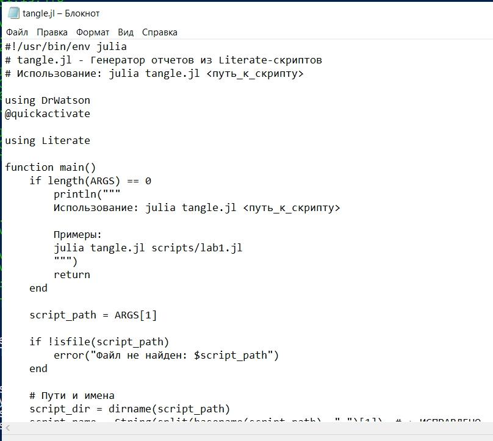

Рисунок 7: tangle.jl

## Базовый прогон модели

Создаем файл sirpetri_run_literate.jl для литературной версии кода (рис. 8).

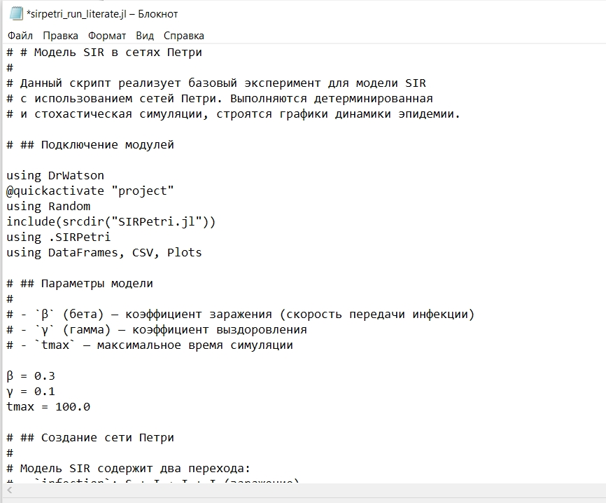

Рисунок 8: Содержимое файла sirpetri_run_literate.jl

## Базовый прогон модели

Генерируем чистый код, jupyter notebook и документацию в формате Quarto с помощью tangle.jl (рис. 9).

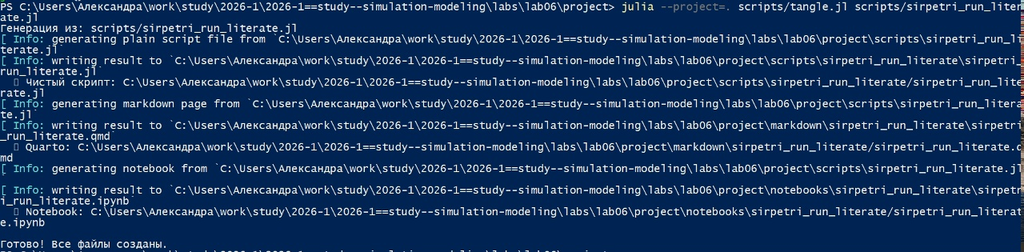

Рисунок 9: Генерация производных форматов

## Базовый прогон модели

Открываем jupyter notebook и проверяем что все коды успешно запускаются (рис. 10).

[figure not shown]

Рисунок 10: Проверка в jupyter notebook

## Коэффициент заражения β

Создаем файл scripts/sirpetri_scan_parameters.jl для исследования чувствительности модели к изменению параметра β (скорости заражения) и добавляем туда скрипт из методички (рис. 11).

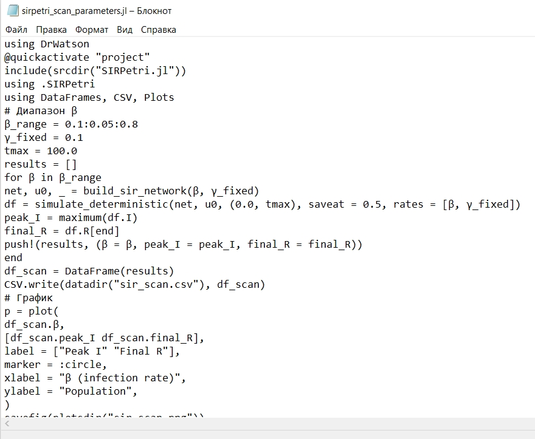

Рисунок 11: Содержимое sirpetri_scan_parameters.jl

## Коэффициент заражения β

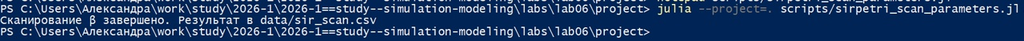

Рисунок 12: Запуск sirpetri_scan_parameters.jl

## Коэффициент заражения β

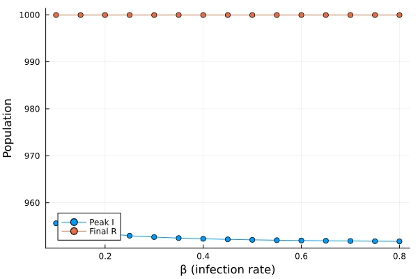

Рисунок 13: Коэффициент заражения β

## Коэффициент заражения β

Создаем файл sirpetri_scan_parameters_literate.jl для литературной версии кода (рис. 14).

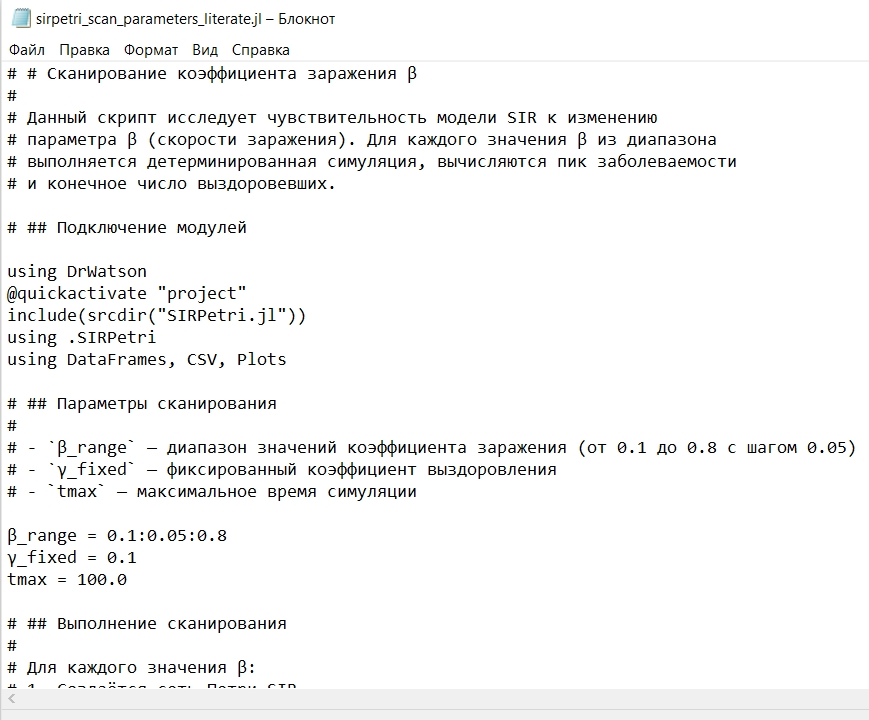

Рисунок 14: Содержимое файла sirpetri_scan_parameters_literate.jl

## Коэффициент заражения β

Генерируем чистый код, jupyter notebook и документацию в формате Quarto с помощью tangle.jl (рис. 15).

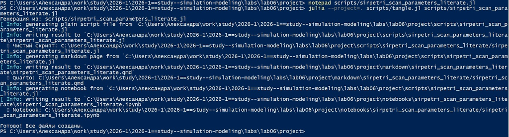

Рисунок 15: Генерация производных форматов

## Коэффициент заражения β

Открываем jupyter notebook и проверяем что все коды успешно запускаются (рис. 16).

[figure not shown]

Рисунок 16: Проверка в jupyter notebook

## Анимация детерминированной динамики

Создаем файл scripts/sirpetri_animate.jl для реализации анимации детерминированной динамики (рис. 17).

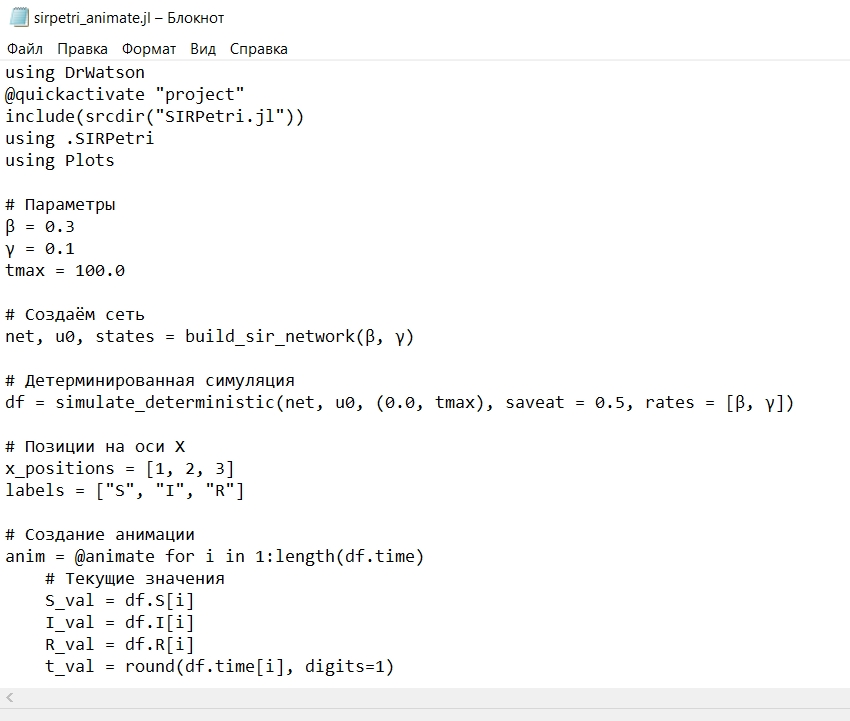

Рисунок 17: Содержимое sirpetri_animate.jl

## Анимация детерминированной динамики

Запускаем scripts/sirpetri_animate.jl командой “julia –project=. scripts/sirpetri_animate.jl”. Анимация сохраняется в папку “plots” (рис. 18).

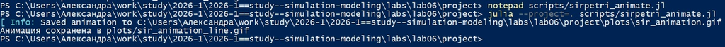

Рисунок 18: Запуск sirpetri_animate.jl

## Анимация детерминированной динамики

Просмотр анимации:

Rutube: <https://rutube.ru/video/private/8a6ff49f3be3812a05bf3c5a13977375/?p=h_-MMq_S2hGfnPH_foYmUQ>

VK Видео: <https://m.vkvideo.ru/video297578553_456239532?list=ln-xk2ErRKGrQRzFc5Raf&pl=297578553_5>

## Анимация детерминированной динамики

Создаем файл sirpetri_animate_literate.jl для литературной версии кода (рис. 19).

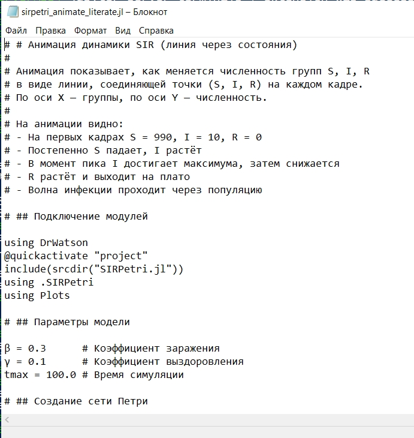

Рисунок 19: Содержимое файла sirpetri_animate_literate.jl

## Анимация детерминированной динамики

Генерируем чистый код, jupyter notebook и документацию в формате Quarto с помощью tangle.jl (рис. 20).

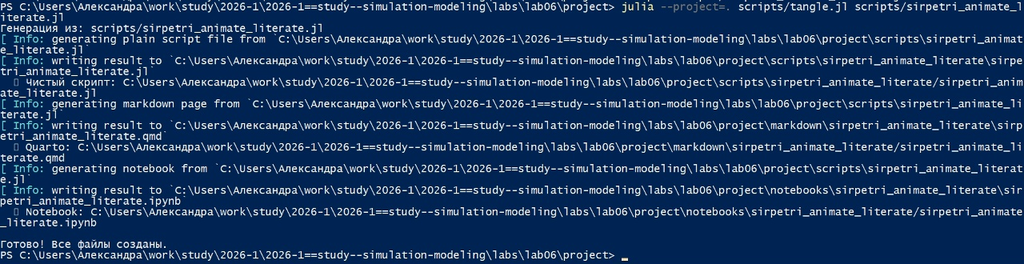

Рисунок 20: Генерация производных форматов

## Анимация детерминированной динамики

Открываем jupyter notebook и проверяем что все коды успешно запускаются (рис. 21).

[figure not shown]

Рисунок 21: Проверка в jupyter notebook

## Итоговый отчёт

Создаем файл scripts/sirpetri_report.jl для реализации итогового отчета (рис. 22).

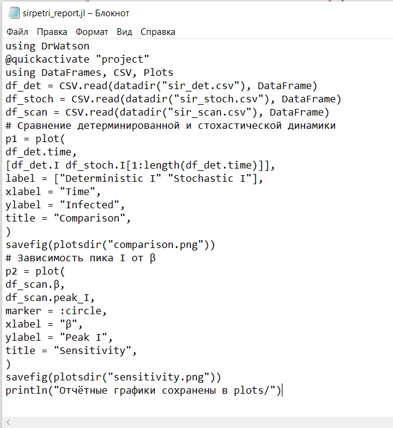

Рисунок 22: Содержимое файла sirpetri_report.jl

## Итоговый отчёт

Запускаем scripts/sirpetri_report.jl командой “julia –project=. scripts/sirpetri_report.jl”. Графики сохраняются в папку “plots” (рис. 23).

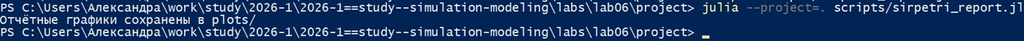

Рисунок 23: Запуск sirpetri_report.jl

## Итоговый отчёт

Просмотрим результаты.

## Итоговый отчёт

comparison.png (рис. 24).

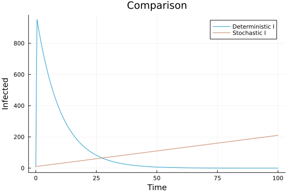

Рисунок 24: Детерминированный и стохастический графики

## Итоговый отчёт

sensitivity.png (рис. 25).

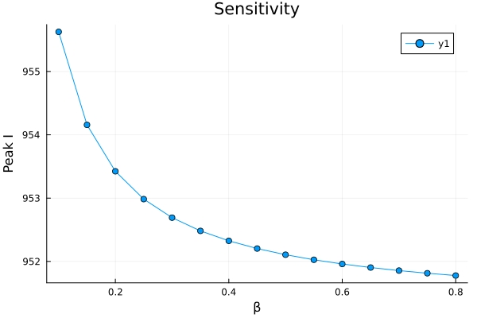

Рисунок 25: Зависимость пика I от β

## Итоговый отчёт

Создаем файл sirpetri_report_literate.jl для литературной версии кода (рис. 26).

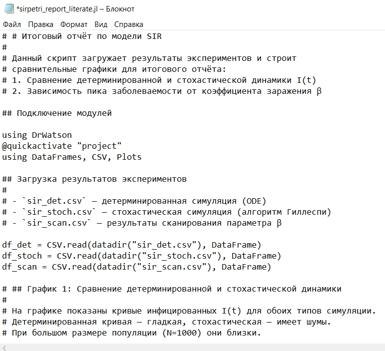

Рисунок 26: Содержимое файла sirpetri_report_literate.jl

## Итоговый отчёт

Генерируем чистый код, jupyter notebook и документацию в формате Quarto с помощью tangle.jl (рис. 27).

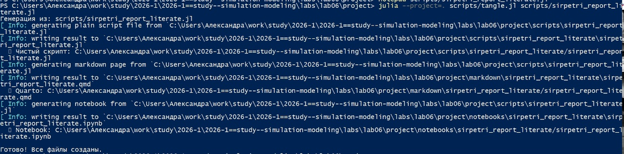

Рисунок 27: Генерация производных форматов

## Итоговый отчёт

[figure not shown]

Рисунок 28: Проверка в jupyter notebook

## Выводы

В ходе выполнения лабораторной работы реализована и исследована эпидемиологическая модель SIR с использованием аппарата сетей Петри.